# R Notebook

```r
# Cargamos las librerías
library(tidyverse)
library(knitr)
library(funModeling)
```

```r
library(ggplot2)
library(ggthemes)
library(descr)
library(haven)
library(foreign)
library(summarytools)
library(reshape2)
options(knitr.kable.NA = '')

library(readr)
library(dplyr)
library(tidyr)
library(readxl)
library(jsonlite)
```

# **Introducción**

## Relevancia y Planificación:

Las técnicas de estudio consisten en aplicar diversos métodos con el objetivo de ayudar al estudiante a lograr una aproximación a sus diversos gastos y al mismo tiempo incrementar soluciones para generar mayores ahorros y planes de presupuesto, así como su motivación para seguir aprendiendo. Estas estrategias se pueden aplicar en cualquier área de estudio, porque nos ayuda a administrar el tiempo y dinero de forma más eficiente, y definir prioridades para estudiar y ahorrar de manera más organizada. El presente informe de estudio es de tipo correlacional, el cual tiene un diseño de investigación experimental y de corte institucional interno.

# Relevancia

La relevancia de este tema de investigación es poder conocer los gastos semanales y mensuales que llega a tener un estudiante de la Universidad De Ingeniería y Tecnología (UTEC), es decir gastos en su comida, movilidad, plan de datos, accesorios personales, artículos de aseo, salud, entre otros. Esta investigación tomará en cuenta a alumnos de todos los ciclos académicos, tanto a los que cuenten con algún tipo de beca o no. La viabilidad de esta misma es poder llevar a cabo esta investigación en donde la principal herramienta será una encuesta con múltiples opciones para no incomodar al encuestado, además para que la toma de datos sea aún más precisa también habrá preguntas con opciones reducidas y de carácter obligatorio, en donde las variables serán los datos recolectados. Nuestra pregunta de investigación sería: ¿Cuáles son los gastos que llega a tener un estudiante de la Universidad de Ingeniería y Tecnología ?

# **Datos**

### Proceso de recolección de datos

Durante nuestro proceso de recolección de datos se realizó mediante encuestas, lo más factible fueron los formularios de Google. La cual es una herramienta sumamente valiosa para elaborar una serie de preguntas concretas, con los datos recolectados se nos proporcionó la suficiente información acerca de los diferentes gastos que tiene un estudiante. Y una vez recolectado estos datos, se hace uso de dicha información para el planteamiento del proyecto de investigación. La principal estrategia utilizada para la recolección de datos fue el envío de estas mismas a cada correo estudiantil para así tener una mayor respuesta por parte de los estudiantes, además de la difusión por redes sociales como es los estados de Whatsapp o también por servicios de mensajería. Con ello se logró tener un mayor alcance y acercamiento a nuestro público objetivo, ya que de esta manera, tenemos un mayor acercamiento o llegada hacia nuestro público objetivo. Por lo que se nos facilitó el contacto con este mismo todo con el fin de conocer a nuestra muestra.

### Variables

- Variables de estudio

  - | Variable | Tipo | Escala | Restricción |
    | --- | --- | --- | --- |
    | Edad | Numérica | Discreta | Entero no negativo - mayor igual a 16 y menor igual al 27 |
    | Género | Categórica | Nominal | Solo puede marcar las opciones dadas |
    | Carrera | Categórica | Nominal | Solo puede marcar las opciones dadas |
    | Lugar de residencia | Categórica | Nominal | Solo puede marcar las opciones dadas |
    | Año de ingreso | Numérica | Discreta | Solo puede marcar las opciones dadas |
    | Gastos en plataformas digitales, Gastos en fin de semana, Gastos de luz, Gastos de agua, Gastos de gas | Numérica | Discreta | Ser un número entero positivo - Solo puede ingresar respuesta |
    | Ingreso mensual | Numérica | Continua | Ser un número positivo - Solo puede ingresar respuesta |
    | Lugar de almuerzo | Categórica | Nominal | Solo puede marcar las opciones dadas |
    | Tiempo de traslado a la Universidad | Categórica | Nominal | Solo puede marcar las opciones dadas |
    | Gastos en medicina, Gasto en transporte | Categórica | Nominal | Solo puede marcar las opciones dadas |

### Limpieza de base de datos

Se eliminaron las columnas: Dirección de correo electrónico, la marca temporal y las prendas que más se compran, ello porque no proporcionan ningún dato importante para el proyecto, además por existir un error por parte de la comprensión de la pregunta. Se corrigió el nombre de cada una de las variables. Se analizó por variable los datos, por ejemplo con table(DF$Edad):

Empezaremos cargando nuestra Fuente de datos.

```r
BaseEstudiantes <- read_csv("BaseEstudiantes.csv")
View(BaseEstudiantes)
```

```r
dim(BaseEstudiantes)
```

```
## [1] 203  59
```

Ahora usamos el siguiente comando para conocer los nombres de nuestras variables:

```r
#Internet, Agua, Luz, Gas
View(BaseEstudiantes[56:59])
```

```r
ncol(DATOS)
```

```
## [1] 55
```

Seleccionamos las variables con las que vamos a trabajar, para ello utilizamos la función **select**

```r
DF<- select(DATOS, Edad, GENERO, CARRERA, SEXO, Año_Ingreso, Beca, Tipo_Beca, Fr_Ingresos, Ingreso_mensual, Princ_gastos, Lugar_Almuerzo, Gasto_C, Distrito, Tiempo_traslado, Gasto_T, Fr_enfermas, Gasto_medicmentos, Plataformas, Gasto_Plataformas, Curso_Idioma, Gasto_curso, Seguro, Gasto_Seguros, Necesidades, FinDSemana, Gastos_FinDSemana, Alojamiento, Internet, Agua, Luz, Gas)
```

Estos son los nombres de nuestras variables:

```r
names(DF)
```

```
##  [1] "Edad"              "GENERO"            "CARRERA"
##  [4] "SEXO"              "Año_Ingreso"       "Beca"
##  [7] "Tipo_Beca"         "Fr_Ingresos"       "Ingreso_mensual"
## [10] "Princ_gastos"      "Lugar_Almuerzo"    "Gasto_C"
## [13] "Distrito"          "Tiempo_traslado"   "Gasto_T"
## [16] "Fr_enfermas"       "Gasto_medicmentos" "Plataformas"
## [19] "Gasto_Plataformas" "Curso_Idioma"      "Gasto_curso"
## [22] "Seguro"            "Gasto_Seguros"     "Necesidades"
## [25] "FinDSemana"        "Gastos_FinDSemana" "Alojamiento"
## [28] "Internet"          "Agua"              "Luz"
## [31] "Gas"
```

# Análisis descriptivo:

## **Edad:**

Para la variable edad hemos realizado una gráfica de barras como se muestra a continuación, observamos que la mayor parte de los encuestados tiene 18 años:

Esta variable es usada para verificar que se esté cumpliendo con el rango estipulado de las edades de los estudiantes que es de 16 a 27 años, además, con el gráfico podemos observar que hay una mayor parte de encuestados que tienen 18 años. (La cantidad de estudiantes 54 del total)

```r
table(DF$Edad)
```

```
##
## 16 17 18 19 20 21 22 23 24 27
##  2 23 54 48 42 16 11  3  3  1
```

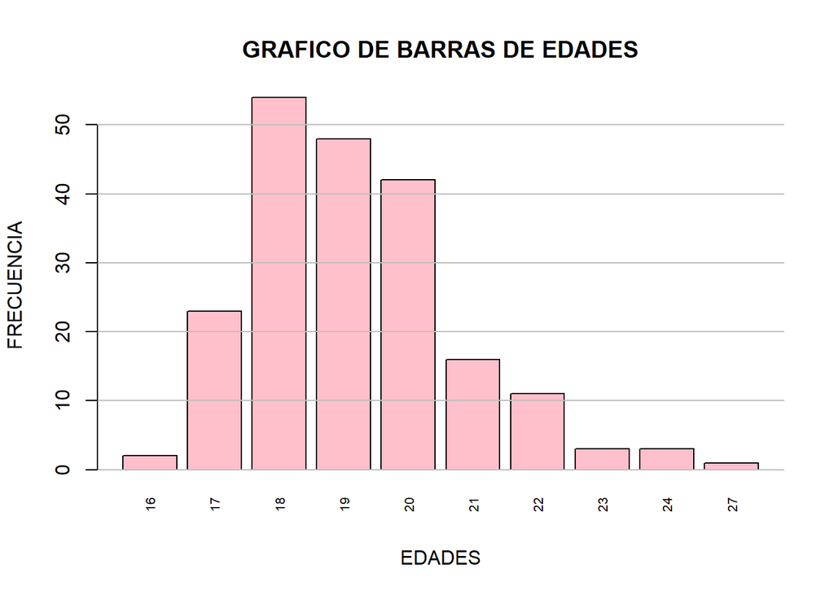

```r
colores <- c("pink")

barplot(table(DF$Edad),main="GRAFICO DE BARRAS DE EDADES", xlab="EDADES",ylab="FRECUENCIA", col = colores, las = 3, cex.names = 0.65)
grid(nx = NA, ny = NULL, lwd = 1, lty = 1, col = "gray")
```

Para observar más a detalle en dónde se encuentra la media y mediana de la variable edad, hemos optado por colocar un histograma. Observamos lo siguiente:

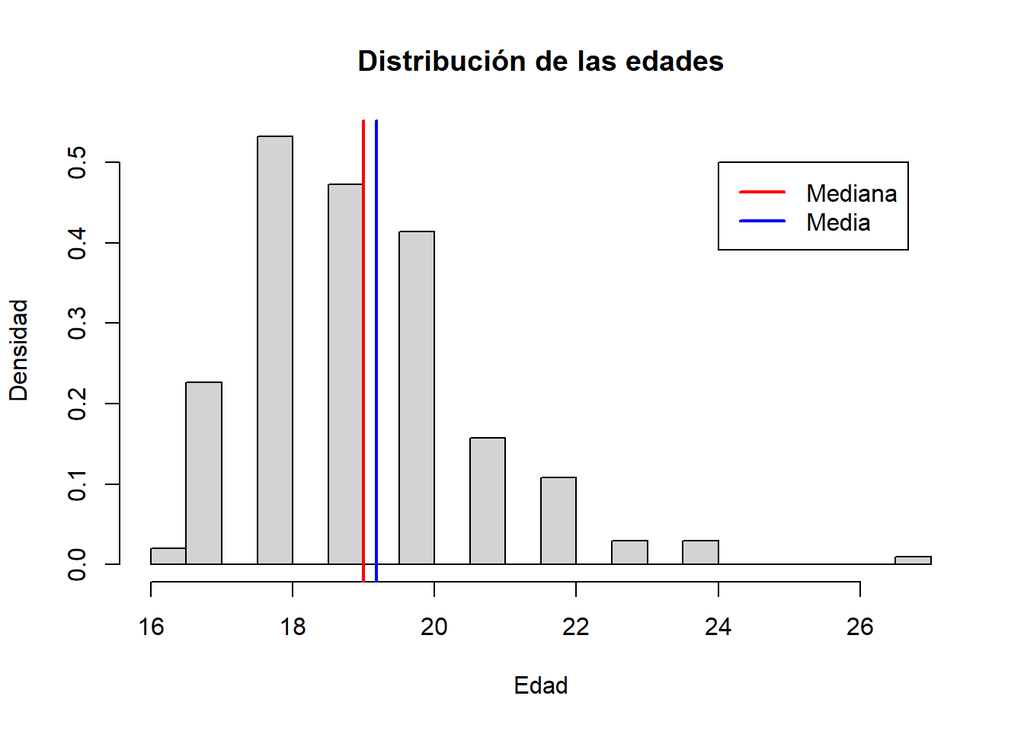

```r
hist(DF$Edad,breaks=30,col="lightgray",main="Distribución de las edades",ylab="Densidad",xlab="Edad",prob=TRUE)
abline(v=median(DF$Edad),col="red",lwd=2)
abline(v=mean(DF$Edad),col="blue",lwd=2)
legend(24,0.5,legend=c("Mediana","Media"),lwd=2,col=c("red","blue"))
```

A continuación los valores de la media y la mediana:

```r
mean(DF$Edad)
```

```
## [1] 19.17734
```

```r
median(DF$Edad)
```

```
## [1] 19
```

Para saber si contamos con valores atípicos dentro de la variable Edad, usamos un boxplot. Aquí podemos observar que hay 2 valores que aparentemente son atípicos, sin embargo consideramos que los valores son correctos, porque hemos tomado en cuenta a los alumnos de todos los ciclos.

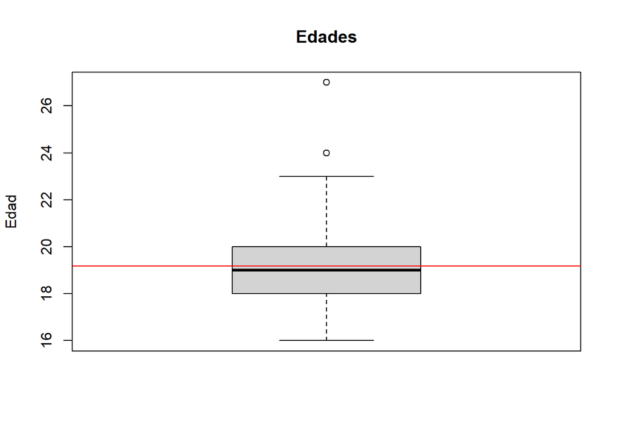

```r
boxplot(DF$Edad,main="Edades",ylab="Edad")


abline(h=mean(DF$Edad),col="red")
```

Usamos la función **summary** para obtener un resumen para la variable Edad. Podemos observar que como mínimo un ingresó la edad de 16, y como valor máximo ingresado se tiene la edad de 27 años.

```r
summary(DF$Edad)
```

```
##    Min. 1st Qu.  Median    Mean 3rd Qu.    Max.
##   16.00   18.00   19.00   19.18   20.00   27.00
```

DESCRIPTORES NUMERICOS EDAD

```r
cat('Mediana de la variable edad:',round(mean(DF$Edad, na.rm=TRUE),2),'\n')
```

```
## Mediana de la variable edad: 19.18
```

```r
cat('Mediana de la variable edad:',round(median(DF$Edad, na.rm=TRUE),2),'\n')
```

```
## Mediana de la variable edad: 19
```

```r
cat('Moda de la variable edad:',18 ,'\n')
```

```
## Moda de la variable edad: 18
```

```r
cat('Varianza de la variable edad:',round(var(DF$Edad, na.rm=TRUE),2),'\n')
```

```
## Varianza de la variable edad: 2.72
```

```r
cat('Desviación estándar de la variable edad:',round(sd(DF$Edad, na.rm=TRUE),2),'\n')
```

```
## Desviación estándar de la variable edad: 1.65
```

```r
cat('Coeficiente de variación de la variable edad:', round((sd(DF$Edad, na.rm=TRUE)/mean(DF$Edad, na.rm=TRUE))*100,2),'\n')
```

```
## Coeficiente de variación de la variable edad: 8.6
```

## **Sexo**

Respecto a la variable”Sexo” contamos con 203 encuestados de los cuales, 93 son mujeres mientras que varones es 110 personas.

```r
table(DF$SEXO)
```

```
##
## Hombre  Mujer
##    110     93
```

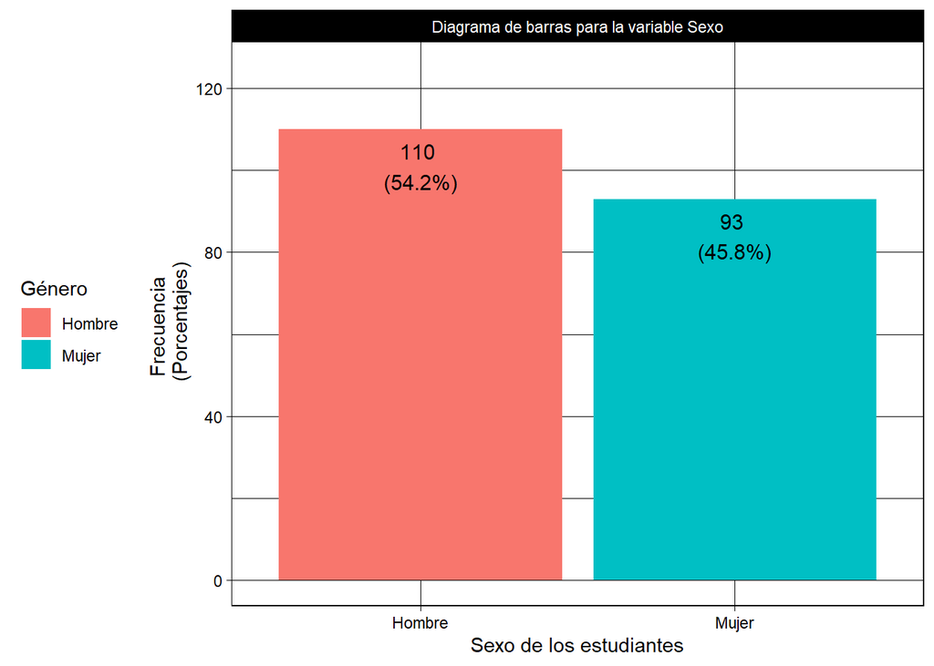

```r
Tabla <- DF %>% group_by(SEXO) %>% summarise(Total=n()) %>%
    dplyr::mutate(Porcentaje = round(Total/sum(Total)*100, 1))

ggplot(Tabla, aes(x = SEXO, y=Total, fill=SEXO) ) +
  geom_bar(width = 0.9, stat="identity", position = position_dodge())+

  ylim(c(0,125))+
  labs(x="Sexo de los estudiantes", y= "Frecuencia \n (Porcentajes)") +
  labs(fill = "")+

  geom_text(aes(label=paste0(Total," ", "", "\n(", Porcentaje, "%",")")),
            vjust=1.3,
            color="black",
            hjust=0.5,
            position = position_dodge(0.9),
            angle=0,
            size=4.0
            ) +
  scale_fill_discrete(name = "Género", labels = c("Hombre","Mujer")) +

  theme(axis.text.x = element_text(angle = -45, vjust = 1, hjust=-0.3)) +
  theme_linedraw() +
  theme(legend.position = "left") +
  facet_grid(~"Diagrama de barras para la variable Sexo")
```

DESCRIPTORES NUMERICOS

```r
cat('Número de observaciones:', nrow(DF),'\n')
```

```
## Número de observaciones: 203
```

```r
cat('Número de casos completos de la variable Sexo:', sum(complete.cases(DF$SEXO)),'\n')
```

```
## Número de casos completos de la variable Sexo: 203
```

```r
cat('Moda de la variable Sexo:', "HOMBRE" ,'\n')
```

```
## Moda de la variable Sexo: HOMBRE
```

## **Año de ingreso**

La mayor parte de los encuestados ingresaron en el año 2021.

```r
table(DF$Año_Ingreso)
```

```
##
## 2016 2018 2019 2020 2021 2022
##    1    6   16   28  110   42
```

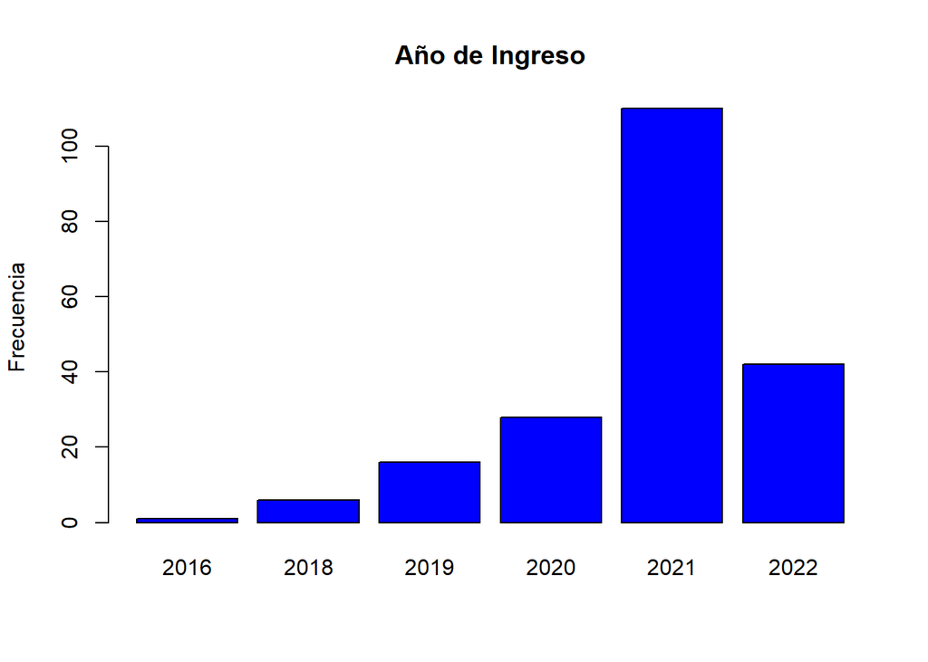

```r
barplot(table(DF$Año_Ingreso),main="Año de Ingreso",ylab="Frecuencia",col = "blue")
```

```r
# barplot, devuelve un gráfico de barras de una tabla de frecuencias
```

La moda es:

```r
x<-DF$Año_Ingreso
mode <- function(x) {
   return(as.numeric(names(which.max(table(x)))))
}
```

```r
s<-mode(x)
s
```

```
## [1] 2021
```

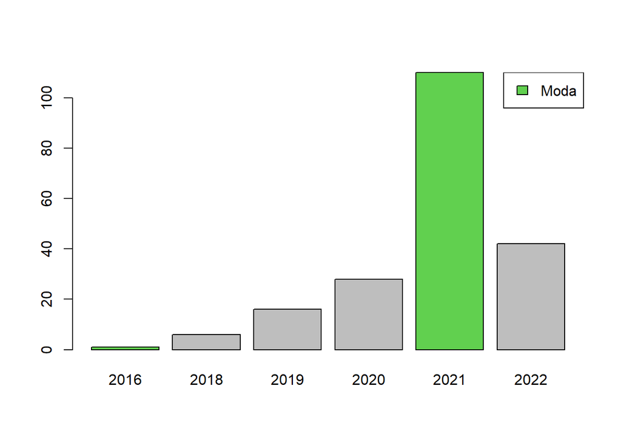

```r
barplot(table(x), col = c(3, rep("gray", 3)))
legend("topright", "Moda", fill = 3)
```

## **Beca**

Del total de estudiantes encuestados, la mayoría cuentan con beca.

```r
table(DF$Beca)
```

```
##
##  No  Si
##  89 114
```

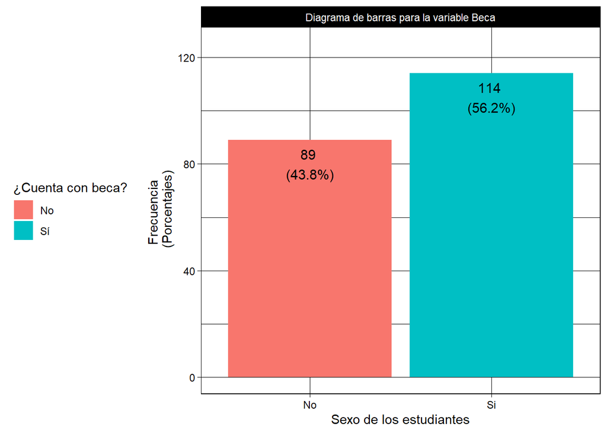

```r
Tabla <- DF %>% group_by(Beca) %>% summarise(Total=n()) %>%
    dplyr::mutate(Porcentaje = round(Total/sum(Total)*100, 1))

ggplot(Tabla, aes(x = Beca, y=Total, fill=Beca) ) +
  geom_bar(width = 0.9, stat="identity", position = position_dodge())+

  ylim(c(0,125))+
  labs(x="Sexo de los estudiantes", y= "Frecuencia \n (Porcentajes)") +
  labs(fill = "")+

  geom_text(aes(label=paste0(Total," ", "", "\n(", Porcentaje, "%",")")),
            vjust=1.3,
            color="black",
            hjust=0.5,
            position = position_dodge(0.9),
            angle=0,
            size=4.0
            ) +
  scale_fill_discrete(name = "¿Cuenta con beca?", labels = c("No", "Sí")) +

  theme(axis.text.x = element_text(angle = -45, vjust = 1, hjust=-0.3)) +
  theme_linedraw() +
  theme(legend.position = "left") +
  facet_grid(~"Diagrama de barras para la variable Beca")
```

DESCRIPTORES NUMERICOS

```r
cat('Número de observaciones:', nrow(DF),'\n')
```

```
## Número de observaciones: 203
```

```r
cat('Número de casos completos de la variable beca:', sum(complete.cases(DF$Beca)),'\n')
```

```
## Número de casos completos de la variable beca: 203
```

```r
cat('Moda de la variable Beca:', "SÍ" ,'\n')
```

```
## Moda de la variable Beca: SÍ
```

## **Carrera**

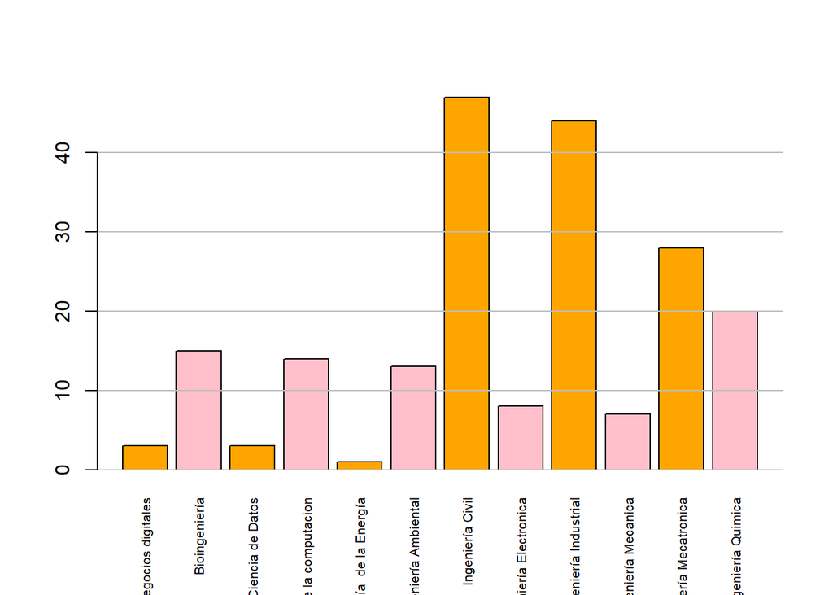

```r
colores <- c("orange", "pink")

barplot(table(DF$CARRERA), col = colores, las = 3, cex.names = 0.65)
grid(nx = NA, ny = NULL, lwd = 1, lty = 1, col = "gray")
```

## **Distrito**

```r
DF$Distrito[DF$Distrito %in% c("Ancón", "Puente Piedra", "Santa Rosa", "Carabayllo", "Comas", "Los Olivos", "Independencia", "San MartÍn de Porres")]<- "Lima Norte"

DF$Distrito[DF$Distrito %in% c("San Juan de Miraflores", "Villa Maria del Triunfo", "Villa el Salvador", "Lurín", "Pachacámac", "Punta Hermosa", "Pucusana", "Punta Negra", "San Bartolo", "Santa María") ]<- "Lima Sur"


DF$Distrito[DF$Distrito %in% c("Barranco", "Breña", "Miraflores", "La Victoria", "Santiago de Surco", "San Borja", "Surquillo", "San Isidro", "Chorrillos", "Cercado de Lima", "San Luis", "Rímac", "Lince", "San Miguel", "Jesús María", "Magdalena del Mar", "Pueblo Libre")]<- "Lima Centro"


DF$Distrito[DF$Distrito %in% c("San Juan de Lurigancho", "Santa Anita", "Cieneguilla", "Ate", "La Molina", "Chaclacayo", "Lurigancho", "El Agustino")]<- "Lima Este"

unique(DF$Distrito)
```

```
## [1] "Lima Centro" "Lima Este"   "Lima Norte"  "Lima Sur"
```

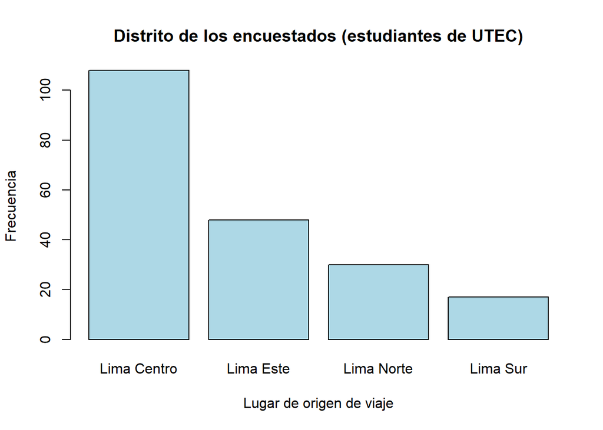

```r
TABLA<-table(DF$Distrito)
barplot(TABLA, main = "Distrito de los encuestados (estudiantes de UTEC)",
     xlab = "Lugar de origen de viaje", ylab = "Frecuencia",
     col = c("lightblue"))
```

RELACIÓN BIVARIADO: *Tiempo de traslado de los estudiantes según el distrito de residencia*

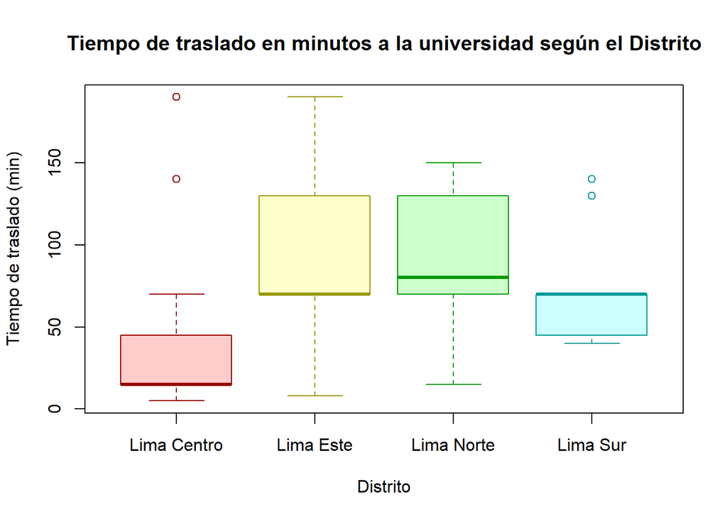

```r
boxplot(DF$Tiempo_traslado ~ DF$Distrito,
        main = "Tiempo de traslado en minutos a la universidad según el Distrito",
        ylab = "Tiempo de traslado (min)",
        xlab = "Distrito",
        col = rainbow(6, alpha=0.2),
        border = rainbow(6, v=0.6)
        )
```

*Gasto en trasporte diario de los estudiantes según el distrito de residencia*

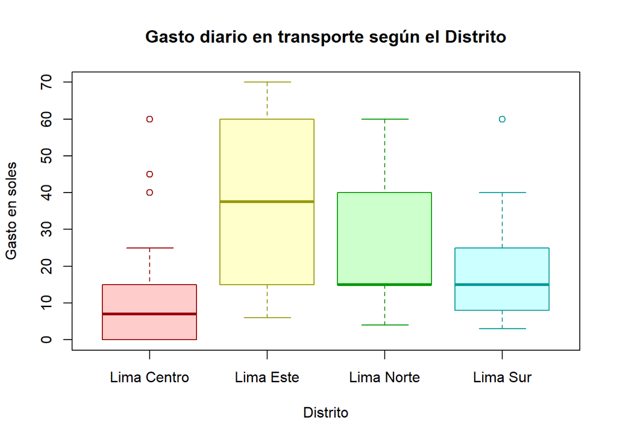

```r
boxplot(DF$Gasto_T ~ DF$Distrito,
        main = "Gasto diario en transporte según el Distrito",
        ylab = "Gasto en soles",
        xlab = "Distrito",
        col = rainbow(6, alpha=0.2),
        border = rainbow(6, v=0.6)
        )
```

## **Frecuencia de Ingresos**

```r
table(DF$Fr_Ingresos)
```

```
##
##    Diario   Mensual Quincenal   Semanal
##        24       124        18        37
```

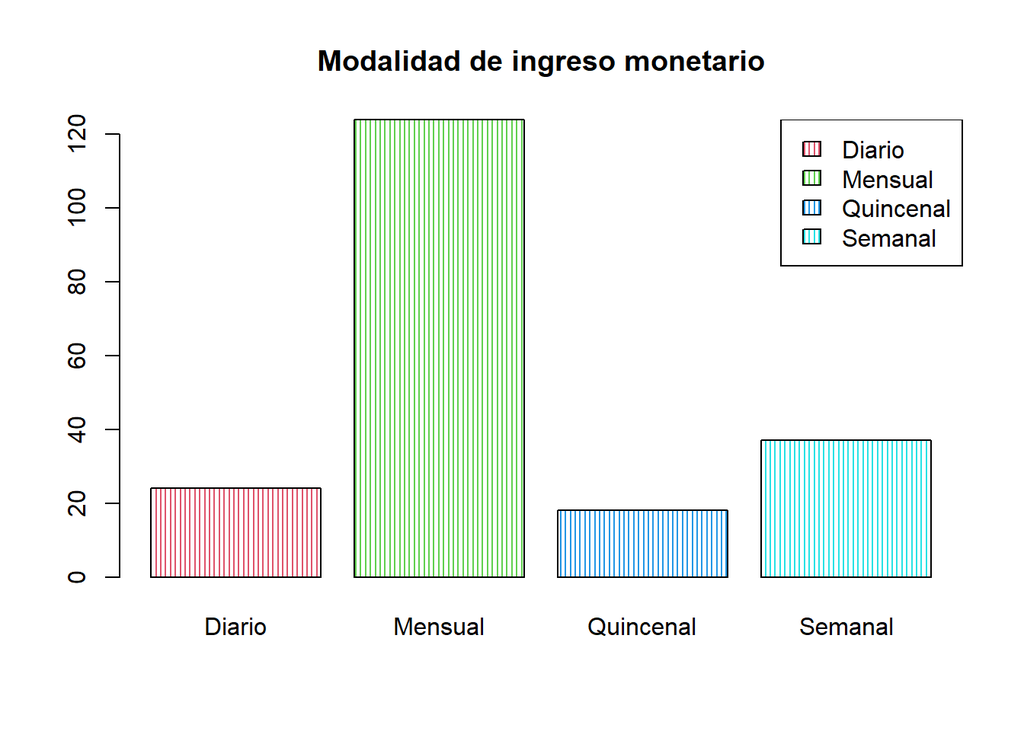

```r
barplot(table(DF$Fr_Ingresos),main = "Modalidad de ingreso monetario", col = 2:5, density = 30, angle = 90)

legend("topright",
       legend = c("Diario", "Mensual", "Quincenal", "Semanal"),
       fill = 2:5,
       density = 30, # Líneas de sombreado
       angle = 90)   # Ángulo de las líneas de sombreado
```

## **Principales gastos**

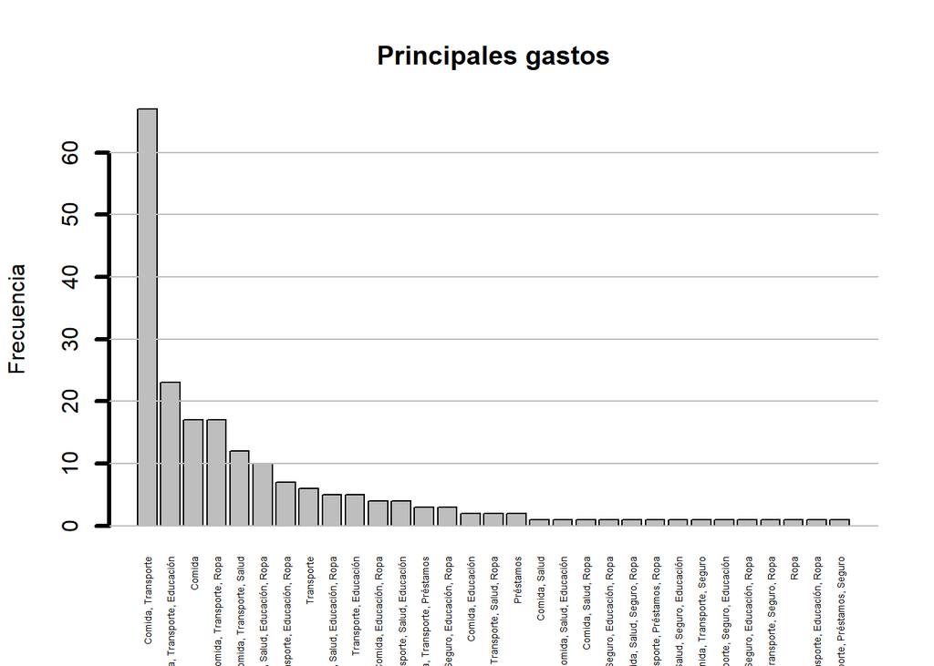

```r
barplot(sort(table(DF$Princ_gastos), decreasing = TRUE), ylab = "Frecuencia", lwd = 3, las = 3, cex.names = 0.45, main = "Principales gastos")
grid(nx = NA, ny = NULL, lwd = 1, lty = 1, col = "gray")
```

## **Alojamiento**

```r
unique(DF$Alojamiento)
```

```
## [1] "Solo"           "Con familiares" "Con padres"     "Con un amigo"
## [5] "Con roomies"
```

Hay más alumnos que viven con sus padres

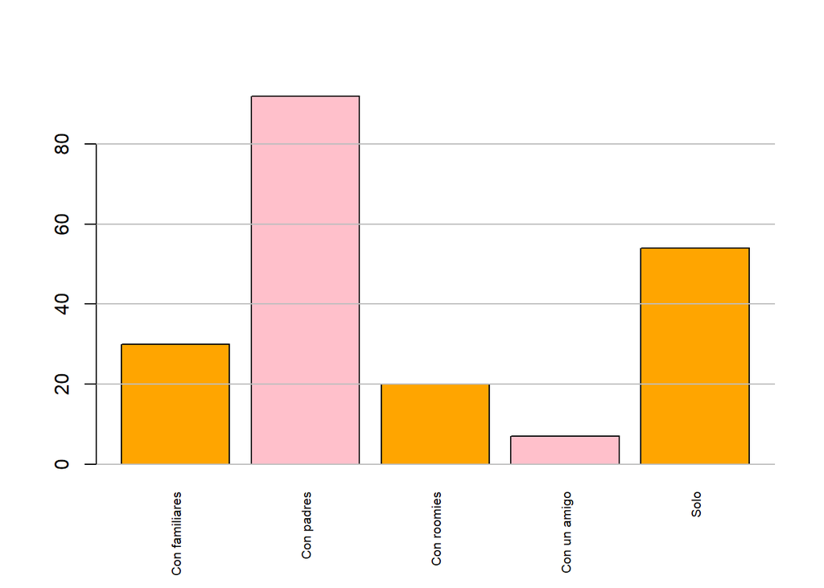

```r
colores <- c("orange", "pink")

barplot(table(DF$Alojamiento), col = colores, las = 3, cex.names = 0.65)
grid(nx = NA, ny = NULL, lwd = 1, lty = 1, col = "gray")
```

## **Ingresos mensuales**

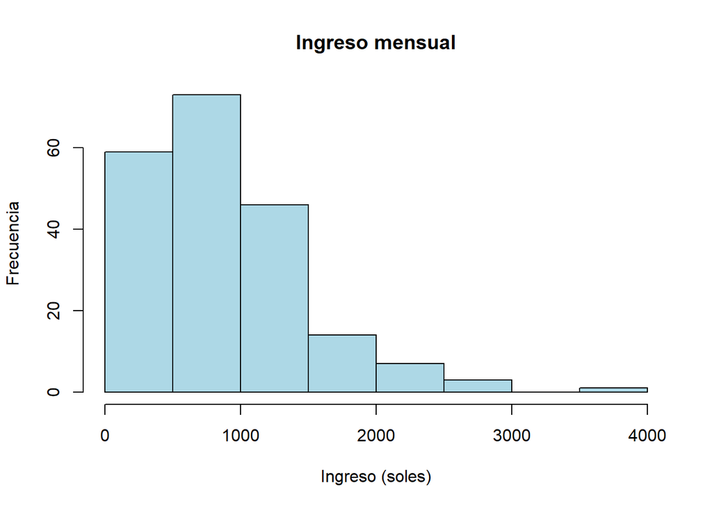

```r
hist(x = DF$Ingreso_mensual, main = "Ingreso mensual", xlab = "Ingreso (soles)", ylab = "Frecuencia", col = "lightblue")
```

## **Gastos en comida**

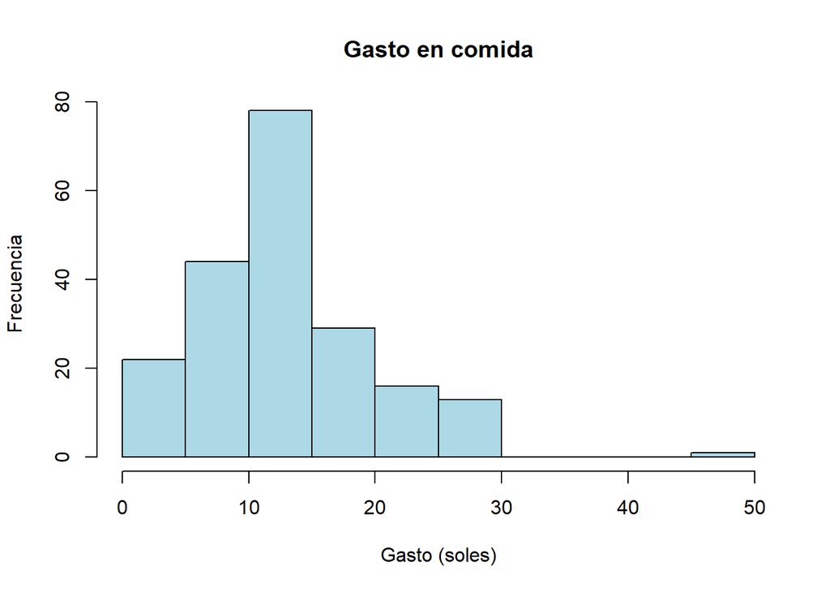

```r
hist(x = DF$Gasto_C, main = "Gasto en comida", xlab = "Gasto (soles)", ylab = "Frecuencia", col = "lightblue")
```

```r
Frecuencias_1<-table(cut(DF$Gasto_C,breaks=seq(from=0,to=60,by=10)))

#breaks=seq(): se utiliza para dar un rango: from=inicio, to=final, by=tamaño del intérvalo.

Frecuencias_1
```

```
##
##  (0,10] (10,20] (20,30] (30,40] (40,50] (50,60]
##      53     107      29       0       1       0
```

```r
Frecuencias<-table(cut(DF$Ingreso_mensual,breaks=seq(from=0,to=2000,by=100)))

#breaks=seq(): se utiliza para dar un rango: from=inicio, to=final, by=tamaño del intervalo.

Frecuencias
```

```
##
##           (0,100]         (100,200]         (200,300]         (300,400]
##                14                 8                11                10
##         (400,500]         (500,600]         (600,700]         (700,800]
##                16                 3                 0                 7
##         (800,900]       (900,1e+03]   (1e+03,1.1e+03] (1.1e+03,1.2e+03]
##                11                52                 0                11
## (1.2e+03,1.3e+03] (1.3e+03,1.4e+03] (1.4e+03,1.5e+03] (1.5e+03,1.6e+03]
##                22                 3                10                 0
## (1.6e+03,1.7e+03] (1.7e+03,1.8e+03] (1.8e+03,1.9e+03]   (1.9e+03,2e+03]
##                 0                 5                 1                 8
```

```r
summary(DF$Edad)
```

```
##    Min. 1st Qu.  Median    Mean 3rd Qu.    Max.
##   16.00   18.00   19.00   19.18   20.00   27.00
```

DESCRIPTORES NUMÉRICOS

```r
cat('Mediana de la variable Gasto en comida:',round(mean(DF$Gasto_C, na.rm=TRUE),2),'\n')
```

```
## Mediana de la variable Gasto en comida: 13.1
```

```r
cat('Mediana de la variable Gasto en comida:',round(median(DF$Gasto_C, na.rm=TRUE),2),'\n')
```

```
## Mediana de la variable Gasto en comida: 13
```

```r
cat('Varianza de la variable Gasto en comida:',round(var(DF$Gasto_C, na.rm=TRUE),2),'\n')
```

```
## Varianza de la variable Gasto en comida: 56.53
```

```r
cat('Desviación estándar de la variable Gasto en comida:',round(sd(DF$Gasto_C, na.rm=TRUE),2),'\n')
```

```
## Desviación estándar de la variable Gasto en comida: 7.52
```

```r
cat('Coeficiente de variación de la variable Gasto en comida:', round((sd(DF$Gasto_C, na.rm=TRUE)/mean(DF$Gasto_C, na.rm=TRUE))*100,2),'\n')
```

```
## Coeficiente de variación de la variable Gasto en comida: 57.4
```

## **Gastos en Luz**

```r
DF$Luz
```

```
##   [1]    3.0   20.0  150.0   60.0    0.0  100.0  100.0    0.0  150.0   20.0
##  [11]    0.0    0.0    0.0   50.0   70.0   60.0   50.0   50.0   20.0   20.0
##  [21]   35.0    0.0    0.0   50.0   30.0  100.0    0.0    0.0   70.0   27.0
##  [31]  400.0  200.0   10.0   50.0  100.0  250.0  400.0  100.0   20.0  150.0
##  [41]   23.0  100.0  100.0    0.0  100.0   25.0  400.0   50.0    0.0  100.0
##  [51]   67.0   50.0  110.0   50.0    0.0   70.0   65.0  100.0   95.0  100.0
##  [61]  200.0  200.0  200.0    0.0   20.0   20.0 3000.0    0.0  230.0   40.0
##  [71]   50.0  200.0    0.0  250.0  170.0   30.0   56.0   45.0  150.0    0.0
##  [81]  180.0   40.0   30.0   70.0    0.0    0.0   75.0   15.0   45.0   50.0
##  [91]   20.0   70.0   45.0  150.0  100.0   60.0    9.0  130.0  350.0  100.0
## [101]    0.0   70.0  300.0  100.0   20.0  100.0  130.0    0.0   30.0    0.0
## [111]  100.0   70.0   55.0    0.0  300.0  100.0  150.0  200.0   50.0   30.0
## [121]   50.0    0.0   35.0   50.0    0.0  150.0  200.0  100.0  300.0    0.0
## [131]  250.0  100.0  200.0  153.4   40.0  200.0   60.0   15.0   50.0  150.0
## [141]   50.0  120.0   20.0  500.0  360.0    0.0  105.0  200.0  208.0   56.0
## [151] 6000.0   30.0  200.0    0.0  100.0  100.0    0.0   20.0  200.0  150.0
## [161]   76.0    0.0   80.0  250.0  100.0   40.0    0.0    0.0  200.0  300.0
## [171]    0.0   30.0   60.0    0.0   75.0  130.0   40.0   50.0  250.0  170.0
## [181]   35.0  100.0   50.0  210.0   40.0  100.0   40.0   40.0  200.0   30.0
## [191]   37.0  220.0  100.0   40.0   45.0   70.0    0.0  150.0    0.0  210.0
## [201]    0.0   45.0   70.0
```

```r
x <- DF$Luz
which(x==3000.0)
```

```
## [1] 67
```

```r
which(x==6000.0)
```

```
## [1] 151
```

Analizamos los datos ingresados por cada alumno: Alumno en la fila 67:

```r
DF[67,]
```

| Edad | GENERO | CARRERA | SEXO | Año_Ingreso | Beca | Tipo_Beca | Fr_Ingresos | Ingreso_mensual | Princ_gastos | Lugar_Almuerzo | Gasto_C | Distrito | Tiempo_traslado | Gasto_T | Fr_enfermas | Gasto_medicmentos | Plataformas | Gasto_Plataformas | Curso_Idioma | Gasto_curso | Seguro | Gasto_Seguros | Necesidades | FinDSemana | Gastos_FinDSemana | Alojamiento | Internet | Agua | Luz | … |
| --- | --- | --- | --- | --- | --- | --- | --- | --- | --- | --- | --- | --- | --- | --- | --- | --- | --- | --- | --- | --- | --- | --- | --- | --- | --- | --- | --- | --- | --- | --- |
| 17 | Femenino | Ingeniería Industrial | Mujer | 2022 | Si | Beca 18 | Mensual | 2000 | Préstamos | En casa | 12 | Lima Centro | 45 | 15 | Una vez cada 15 días | 15 | No | 0 | Sí | 160 | Sí | 120 | Necesidades Basicas | Cines | 1200 | Solo | 500 | 450 | 3000 | … |

Consideramos que fue un error al momento de digitar, pues en gasto mensual de Internet, Agua y Luz, los valores que ingresó no excedió los 3 dígitos. Entonces procedemos a corregir el valor.

```r
DF$Luz[67] <- 300
```

Alumno en la fila 151:

```r
DF[151,]
```

| Edad | GENERO | CARRERA | SEXO | Año_Ingreso | Beca | Tipo_Beca | Fr_Ingresos | Ingreso_mensual | Princ_gastos | Lugar_Almuerzo | Gasto_C | Distrito | Tiempo_traslado | Gasto_T | Fr_enfermas | Gasto_medicmentos | Plataformas | Gasto_Plataformas | Curso_Idioma | Gasto_curso | Seguro | Gasto_Seguros | Necesidades | FinDSemana | Gastos_FinDSemana | Alojamiento | Internet | Agua | Luz | … |
| --- | --- | --- | --- | --- | --- | --- | --- | --- | --- | --- | --- | --- | --- | --- | --- | --- | --- | --- | --- | --- | --- | --- | --- | --- | --- | --- | --- | --- | --- | --- |
| 18 | Masculino | Ingeniería Mecanica | Hombre | 2021 | No | NA | Quincenal | 1000 | Comida, Transporte, Ropa | En un restaurante | 30 | Lima Este | 45 | 60 | Una vez cada 3 meses | 45 | No | 0 | No | NA | Sí | 250 | Necesidades Basicas | Alcohol | 100 | Con padres | 200 | 3000 | 6000 | … |

Aquí eliminamos la fila 151, puesto que ingresó valores muy grandes…

```r
Data <- DF[-151,]
```

Gráfico ya corregido:

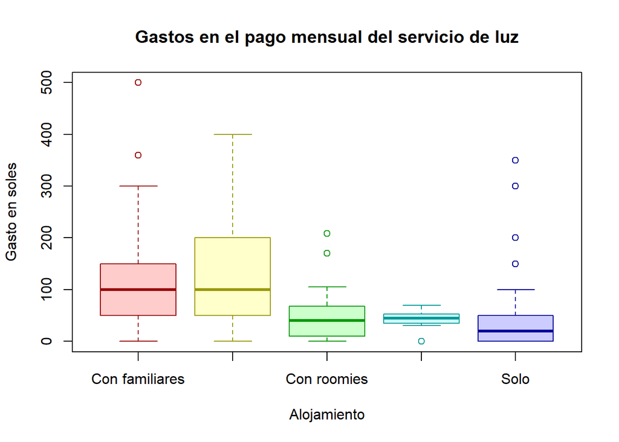

```r
boxplot(Data$Luz~Data$Alojamiento,
        main = "Gastos en el pago mensual del servicio de luz",
        ylab = "Gasto en soles",
        xlab = "Alojamiento",
        col = rainbow(6, alpha=0.2),
        border = rainbow(6, v=0.6)
        )
```

Este diagrama “box-plot” es usado mayormente para observar datos atípicos de los datos recolectados en la muestra, es decir resaltar aspectos de la distribución de las observaciones en una o más series de datos cuantitativo.Por ello, para analizar la relación de gasto en soles de la variable consumo de luz y alojamiento se utilizo un diagrama de “box-plot”.

DESCRIPTORES NUMÉRICOS

```r
cat('Mediana de la variable Gasto en Luz:',round(mean(DF$Luz, na.rm=TRUE),2),'\n')
```

```
## Mediana de la variable Gasto en Luz: 119.36
```

```r
cat('Mediana de la variable Gasto en Luz:',round(median(DF$Luz, na.rm=TRUE),2),'\n')
```

```
## Mediana de la variable Gasto en Luz: 60
```

```r
cat('Varianza de la variable Gasto en Luz:',round(var(DF$Luz, na.rm=TRUE),2),'\n')
```

```
## Varianza de la variable Gasto en Luz: 180796.5
```

```r
cat('Desviación estándar de la variable Gasto en Luz:',round(sd(DF$Luz, na.rm=TRUE),2),'\n')
```

```
## Desviación estándar de la variable Gasto en Luz: 425.2
```

```r
cat('Coeficiente de variación de la variable Gasto en Luz:', round((sd(DF$Luz, na.rm=TRUE)/mean(DF$Luz, na.rm=TRUE))*100,2),'\n')
```

```
## Coeficiente de variación de la variable Gasto en Luz: 356.23
```

## **Gastos de Internet**

Buscamos en qué fila se encuentra ese valor:

```r
x1 <- Data$Internet
which(x1 == 2000)
```

```
## [1] 115
```

```r
#Sen encuentra en la fila 115
```

Analizamos los valores numéricos que ingresó el estudiante:

```r
Data[115,]
```

| Edad | GENERO | CARRERA | SEXO | Año_Ingreso | Beca | Tipo_Beca | Fr_Ingresos | Ingreso_mensual | Princ_gastos | Lugar_Almuerzo | Gasto_C | Distrito | Tiempo_traslado | Gasto_T | Fr_enfermas | Gasto_medicmentos | Plataformas | Gasto_Plataformas | Curso_Idioma | Gasto_curso | Seguro | Gasto_Seguros | Necesidades | FinDSemana | Gastos_FinDSemana | Alojamiento | Internet | Agua | Luz | … |
| --- | --- | --- | --- | --- | --- | --- | --- | --- | --- | --- | --- | --- | --- | --- | --- | --- | --- | --- | --- | --- | --- | --- | --- | --- | --- | --- | --- | --- | --- | --- |
| 19 | Masculino | Ciencias de la computacion | Hombre | 2020 | No | NA | Mensual | 200 | Comida | En el comedor de la universidad | 13 | Lima Este | 8 | 60 | Una vez cada 15 días | 5 | No | 0 | No | NA | Sí | 170 | Necesidades Basicas | Nada | 0 | Con padres | 2000 | 400 | 300 | … |

En su respuesta numérica para gasto mensual en Internet se observa que ingresó 2000 soles, lo cual consideramos que se equivocó al digitar, pues analizando los otros valores numéricos que ingresó para gastos mensual en Agua, Luz y Gas, son números que no pasan de 3 dígitos. Por ello cambiaremos este valor a 200.

```r
Data$Internet[115] <- 200
```

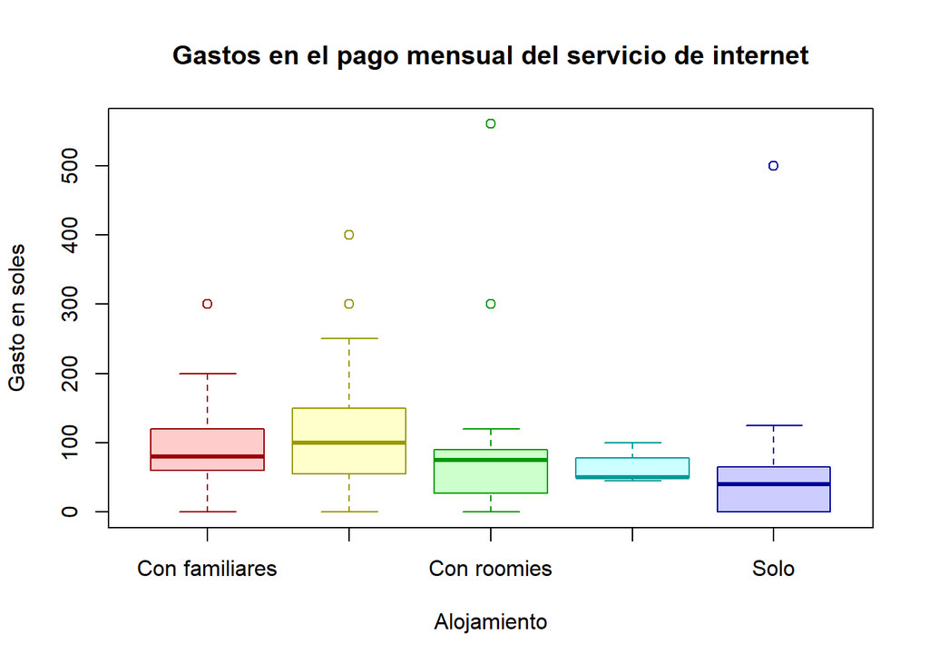

```r
boxplot(Data$Internet~Data$Alojamiento,
        main = "Gastos en el pago mensual del servicio de internet",
        ylab = "Gasto en soles",
        xlab = "Alojamiento",
        col = rainbow(6, alpha=0.2),
        border = rainbow(6, v=0.6)
        )
```

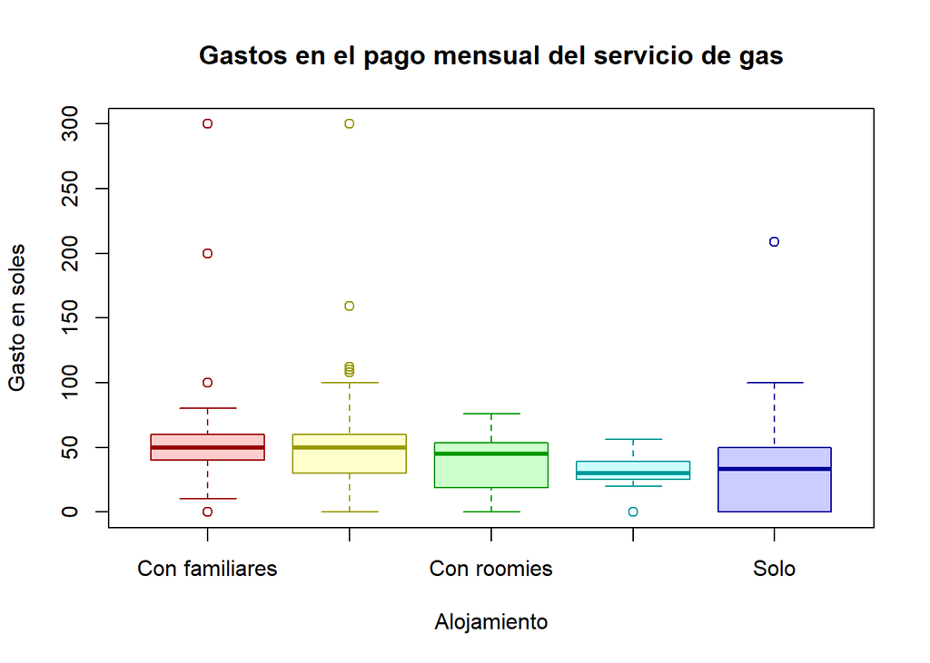

```r
boxplot(Data$Gas ~ Data$Alojamiento,
        main = "Gastos en el pago mensual del servicio de gas",
        ylab = "Gasto en soles",
        xlab = "Alojamiento",
        col = rainbow(6, alpha=0.2),
        border = rainbow(6, v=0.6)
        )
```

Este diagrama “box-plot” es usado mayormente para observar datos atípicos de los datos recolectados en la muestra, es decir resaltar aspectos de la distribución de las observaciones en una o más series de datos cuantitativo.Por ello, para analizar la relación de gasto en soles de la variable consumo de gas y alojamiento se utilizo un diagrama de “box-plot”.

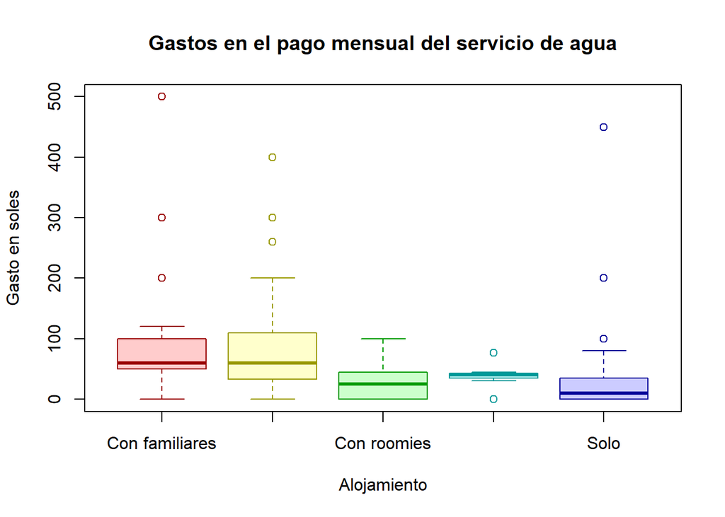

```r
boxplot(Data$Agua ~ Data$Alojamiento,
        main = "Gastos en el pago mensual del servicio de agua",
        ylab = "Gasto en soles",
        xlab = "Alojamiento",
        col = rainbow(6, alpha=0.2),
        border = rainbow(6, v=0.6)
        )
```

Este diagrama “box-plot” es usado mayormente para observar datos atípicos de los datos recolectados en la muestra, es decir resaltar aspectos de la distribución de las observaciones en una o más series de datos cuantitativo.Por ello, para analizar la relación de gasto en soles de la variable consumo de agua y alojamiento se utilizo un diagrama de “box-plot”.

## **GASTOS DE FIN DE SEMANA**

```r
apply(is.na(Data), 2, sum)
```

```
##              Edad            GENERO           CARRERA              SEXO
##                 0                 0                 0                 0
##       Año_Ingreso              Beca         Tipo_Beca       Fr_Ingresos
##                 0                 0                88                 0
##   Ingreso_mensual      Princ_gastos    Lugar_Almuerzo           Gasto_C
##                 0                 0                 0                 0
##          Distrito   Tiempo_traslado           Gasto_T       Fr_enfermas
##                 0                 0                 0                 0
## Gasto_medicmentos       Plataformas Gasto_Plataformas      Curso_Idioma
##                 0                 0                 0                 0
##       Gasto_curso            Seguro     Gasto_Seguros       Necesidades
##               147                 0               108                 0
##        FinDSemana Gastos_FinDSemana       Alojamiento          Internet
##                 0                36                 0                 0
##              Agua               Luz               Gas
##                 0                 0                 0
```

```r
# Cantidad de NA por columna
```

```r
na.omit(Data$Gastos_FinDSemana)
```

```
##   [1] "100"  "100"  "50"   "100"  "100"  "300"  "50"   "30"   "50"   "0"
##  [11] "0"    "30"   "50"   "20"   "20"   "19"   "50"   "20"   "10"   "49"
##  [21] "200"  "500"  "25"   "10"   "40"   "20"   "100"  "30"   "500"  "100"
##  [31] "200"  "5.0"  "50"   "50"   "40"   "0"    "0"    "100"  "50"   "100"
##  [41] "50"   "49"   "20"   "50"   "100"  "10"   "50"   "20"   "30"   "400"
##  [51] "30"   "20"   "20"   "1200" "50"   "20"   "0"    "30"   "50"   "40"
##  [61] "15"   "70"   "50"   "0"    "30"   "60"   "30"   "30"   "0"    "50"
##  [71] "80"   "01"   "0"    "20"   "0"    "100"  "0"    "80"   "50"   "50"
##  [81] "100"  "0"    "100"  "500"  "30"   "500"  "100"  "400"  "0"    "50"
##  [91] "50"   "0"    "40"   "40"   "10"   "20.0" "50"   "20"   "50"   "10"
## [101] "50"   "20"   "100"  "200"  "100"  "300"  "20"   "35"   "25"   "500"
## [111] "420"  "100"  "100"  "50"   "20"   "50"   "200"  "50"   "150"  "66"
## [121] "100"  "100"  "25"   "30"   "25"   "150"  "0"    "30"   "30"   "20"
## [131] "200"  "10"   "30"   "10"   "50"   "50"   "60"   "50"   "12"   "200"
## [141] "30"   "50"   "50"   "100"  "300"  "30"   "20"   "50"   "200"  "60"
## [151] "30"   "100"  "60"   "80"   "100"  "100"  "22"   "40"   "60"   "100"
## [161] "50"   "65"   "80"   "100"  "65"   "100"
## attr(,"na.action")
##  [1]   2   6   8  16  18  21  23  26  28  55  58  63  64  78  89  92  96  97 100
## [20] 104 109 111 113 118 120 126 135 138 139 141 154 164 168 196 198 199
## attr(,"class")
## [1] "omit"
```

```r
# Posiciones en donde se encontró N.A en Gastos_FinDSemana
```

Pra poder graficar, primero convertimos el tipo de variable a una numerica, para poder trabajar con un histograma:

```r
finDe <- as.numeric(DF$Gastos_FinDSemana)
class(finDe)
```

```
## [1] "numeric"
```

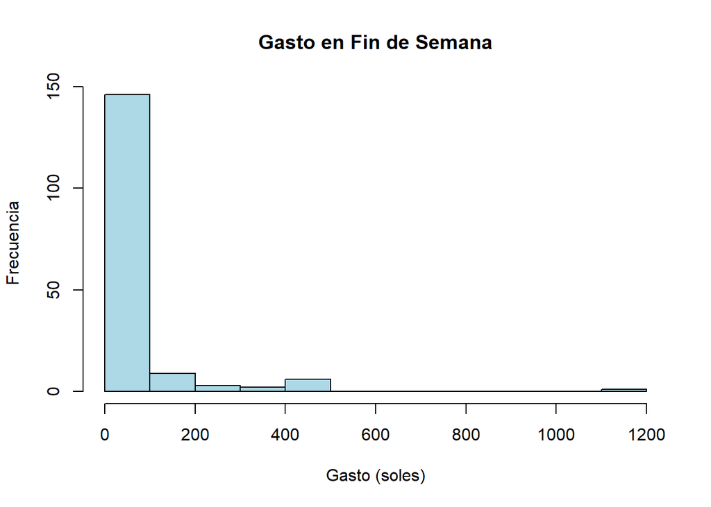

```r
hist(x = finDe , main = "Gasto en Fin de Semana", xlab = "Gasto (soles)", ylab = "Frecuencia", col = "lightblue")
```

## **Necesidades:**

Las necesidades Creadas son los deseos de consumir bienes o servicios que no satisfacen necesidades primarias. Mientras que las necesidades básicas o también conocidas como necesidades primarias y humanas fundamentales las cuales son esenciales para la supervivencia humana.

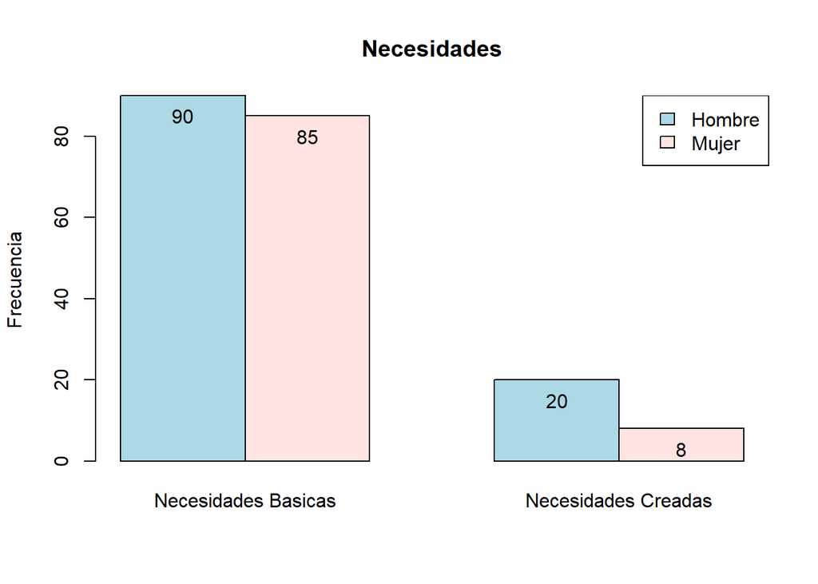

```r
a<-table(DF$SEXO,DF$Necesidades)
barp<-barplot(a,beside=TRUE,main = "Necesidades", ylab='Frecuencia',col = c("lightblue", "mistyrose"))
text(barp, a-5, labels = a)
legend('topright', legend=rownames(a),
       fill=c("lightblue", "mistyrose"))
```

## **Gastos de almuerzo**

```r
DF$Lugar_Almuerzo[DF$Lugar_Almuerzo %in% c("llevo comida", "Delivery", "Chifa", "Menús", "Traigo comida", "Restaurante pero como comida de casa", "A veces restaurante, otras me traigo comida de casa", "Traigo mi almuerzo", "Casa de una amiga")]<-"Otro"
unique(DF$Lugar_Almuerzo)
```

```
## [1] "En un restaurante"               "En casa"
## [3] "En el comedor de la universidad" "Otro"
```

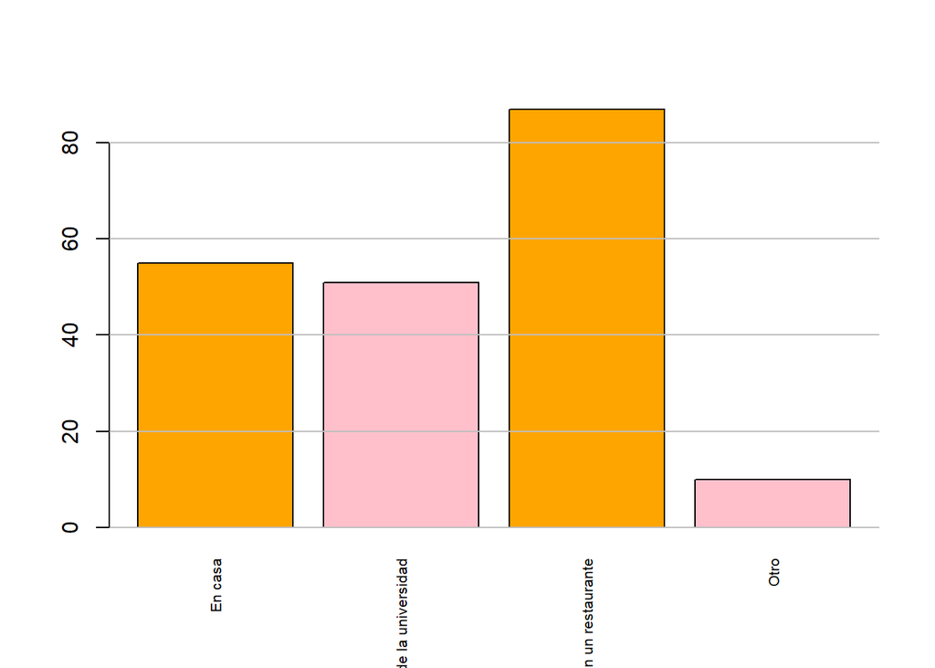

```r
colores <- c("orange", "pink")

barplot(table(DF$Lugar_Almuerzo), col = colores, las = 3, cex.names = 0.65)
grid(nx = NA, ny = NULL, lwd = 1, lty = 1, col = "gray")
```

## **GASTO EN TRANSPORTE**

```r
unique(DF$Gasto_T)
```

```
##  [1]  0 15 25  8 40  4  3 60 35 70  6 45
```

```r
DF$Gasto_T[DF$Gasto_T %in% c("0, me traslado a pie.")]<-"0"
DF$Gasto_T[DF$Gasto_T %in% c("1 a 5 soles")]<-"(1,5]"
DF$Gasto_T[DF$Gasto_T %in% c("5 a 10 soles")]<-"(5,10]"
DF$Gasto_T[DF$Gasto_T %in% c("10 a 20 soles")]<-"(10,20]"
DF$Gasto_T[DF$Gasto_T %in% c("20 a 30 soles")]<-"(20,30]"
DF$Gasto_T[DF$Gasto_T %in% c("30 a 50 soles")]<-"(30,50]"
DF$Gasto_T[DF$Gasto_T %in% c("de 50 soles a más")]<-"(50]"
unique(DF$Gasto_T)
```

```
##  [1] "0"  "15" "25" "8"  "40" "4"  "3"  "60" "35" "70" "6"  "45"
```

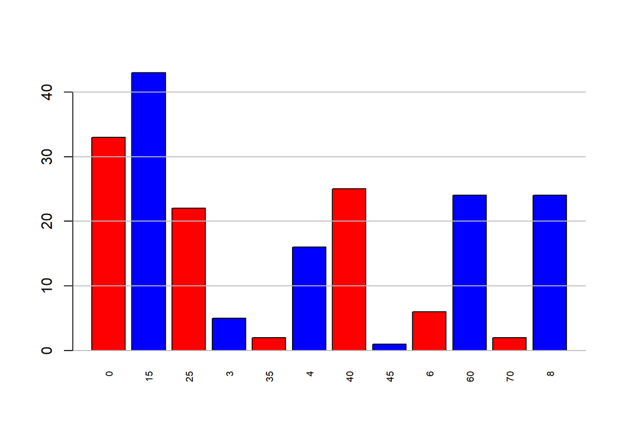

```r
colores <- c("red", "blue")

barplot(table(DF$Gasto_T), col = colores, las = 3, cex.names = 0.65)
grid(nx = NA, ny = NULL, lwd = 1, lty = 1, col = "gray")
```

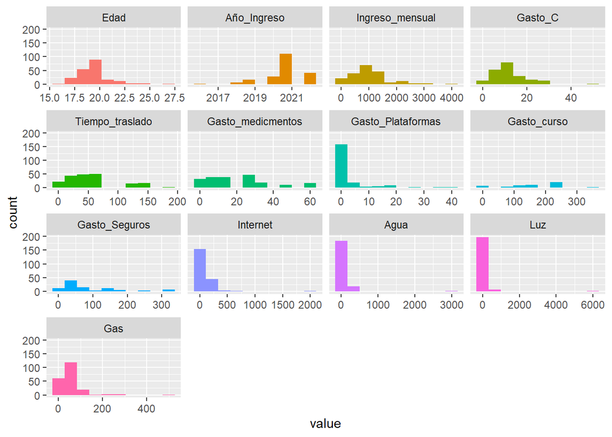

```r
plot_num(DF)
```

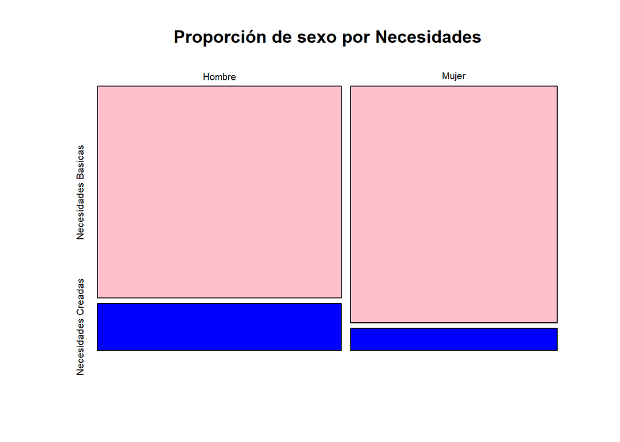

```r
mosaicplot(table(DF$SEXO,DF$Necesidades),main="Proporción de sexo por Necesidades",col=c("pink","blue"))
```

## ENTREGA 2

### **GRUPO N° 3**

### INTEGRANTES:

- Eva Lucero Arevalo Sanchez
- Fiorela Shanthal del Rocio Arizaca Alvarez
- Renzo Antonio Fernadez Gasparetto
- Maria Magallanes Gutierrez

# **Introducción**

## Relevancia y Planificación:

Las técnicas de estudio consisten en aplicar diversos métodos con el objetivo de ayudar al estudiante a lograr una aproximación a sus diversos gastos y al mismo tiempo incrementar soluciones para generar mayores ahorros y planes de presupuesto, así como su motivación para seguir aprendiendo. Estas estrategias se pueden aplicar en cualquier área de estudio, porque nos ayuda a administrar el tiempo y dinero de forma más eficiente, y definir prioridades para estudiar y ahorrar de manera más organizada. El presente informe de estudio es de tipo correlacional, el cual tiene un diseño de investigación experimental y de corte institucional interno.

# Relevancia

La relevancia de este tema de investigación es poder conocer los gastos semanales y mensuales que llega a tener un estudiante de la Universidad De Ingeniería y Tecnología (UTEC), es decir gastos en su comida, movilidad, plan de datos, accesorios personales, artículos de aseo, salud, entre otros. Esta investigación tomará en cuenta a alumnos de todos los ciclos académicos, tanto a los que cuenten con algún tipo de beca o no. La viabilidad de esta misma es poder llevar a cabo esta investigación en donde la principal herramienta será una encuesta con múltiples opciones para no incomodar al encuestado, además para que la toma de datos sea aún más precisa también habrá preguntas con opciones reducidas y de carácter obligatorio, en donde las variables serán los datos recolectados. Nuestra pregunta de investigación sería: ¿Cuáles son los gastos que llega a tener un estudiante de la Universidad de Ingeniería y Tecnología ?

# Planificación

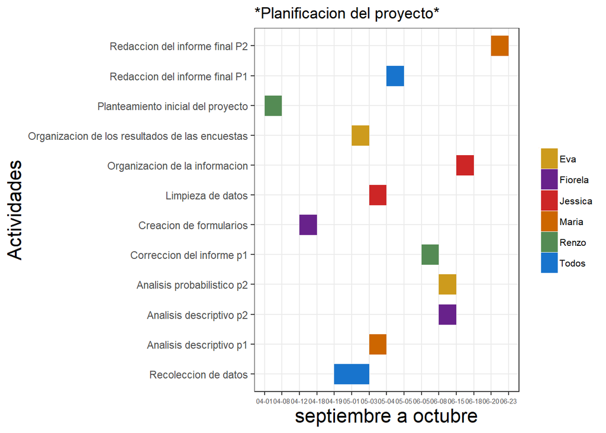

```r
data <- data.frame(Integrantes = c('Planteamiento inicial del proyecto','Creacion de formularios','  Recoleccion de datos','Organizacion de los resultados de las encuestas','Limpieza de datos','Analisis descriptivo p1', 'Redaccion del informe final P1','Correccion del informe p1', 'Analisis descriptivo p2','Analisis probabilistico p2', 'Organizacion de la informacion', 'Redaccion del informe final P2'))
inicio = c('04-01', '04-12', '04-19', '05-01', '05-03','05-03', '05-04','06-05','06-08','06-08','06-15','06-20')
fin = c('04-08', '04-18', '05-03','05-03','05-04','05-04', '05-05','06-08','06-15','06-15','06-18','06-23')
A= c('Renzo','Fiorela','Todos','Eva','Jessica', 'Maria','Todos','Renzo','Fiorela','Eva','Jessica', 'Maria')

ggplot(data, aes(x=inicio, xend=fin, y=Integrantes, yend=Integrantes, color=A)) +
  theme_bw()+  geom_segment(size=8) + labs(title='*Planificacion del proyecto*', x='septiembre a octubre', y='Actividades') + scale_colour_manual(values = c('goldenrod3', 'darkorchid4', 'firebrick3','darkorange3','palegreen4','dodgerblue3','red','blue','lightgreen','brown','grey','lightyellow','royalblue')) +
  theme(axis.title = element_text(size=16))+
  theme(axis.text.x = element_text(size=5.5))+
  theme(legend.text = element_text(size=8))+
  theme(legend.title = element_text(size=0))
```

ANALISIS PROBABILÍSTICO DE LA VARIABLE EDAD:

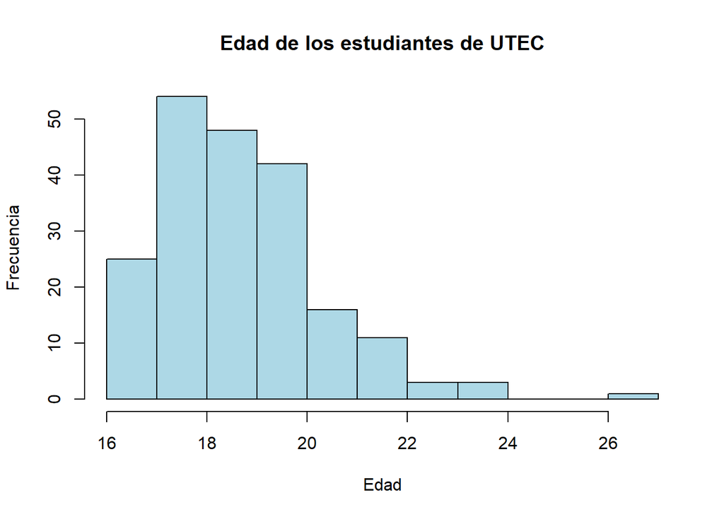

```r
hist(x = DF$Edad, main = "Edad de los estudiantes de UTEC", xlab = "Edad", ylab = "Frecuencia", col = "lightblue")
```

Respecto al análisis de la la variable edad, los intervalos que consideramos son desde los 16 hasta los 27 años, ademas, podemos ver mediante la gráfica de barras que una parte considerable de estudiantes tiene 17 y 18 años, lo cual hace que en nuestro gráfico estas cantidades sobresalgan.

DISTRIBUCIÓN NORMAL

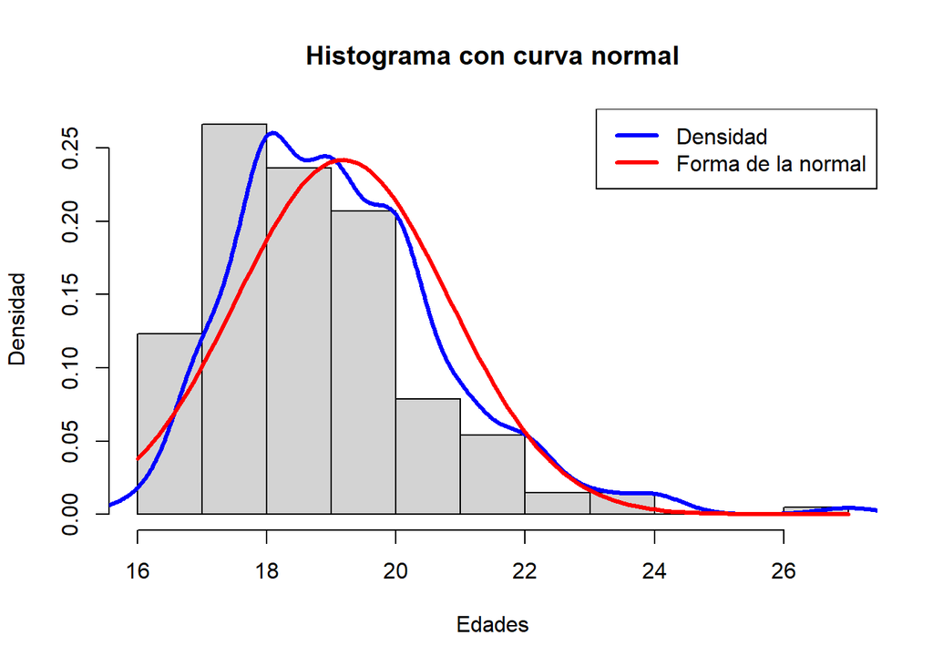

```r
hist(DF$Edad, prob = TRUE,
     main = "Histograma con curva normal", xlab = "Edades", ylab = "Densidad")
x <- seq(min(DF$Edad), max(DF$Edad), length = 40)
f <- dnorm(x, mean = mean(DF$Edad), sd = sd(DF$Edad))
lines(density(DF$Edad, na.rm=T), col="blue",lwd=3)
curve(dnorm(x, mean(DF$Edad, na.rm=T), sd(DF$Edad, na.rm=T)), lwd=3, col="red",add=T)

legend("topright", legend = c("Densidad", "Forma de la normal"), col = c("blue", "red"), lty = 1, lwd = 3)
```

Vemos que la gráfica se asemeja a un gráfico de la normal, por la cual formulamos nuestra pregunta con la normal, necesitaremos la media y la desviación estándar; además, la densidad es menor a 1.

## APLICACIÓN PROBABILISTICA:

**Aplicación de la desviación estándar**

```r
u<-pnorm(20, mean =19.16 ,sd= 19.16)-pnorm(15, mean = 19, sd=1.64)
u
```

```
## [1] 0.5101211
```

RELACIÓN DE LA VARIABLE DISTRITO y GASTOS DE TRANSPORTE

```r
k<-as.numeric(DF$Gasto_T)
b<-table(DF$Distrito,k)
b
```

```
##              k
##                0  3  4  6  8 15 25 35 40 45 60 70
##   Lima Centro 33  4 14  3 14 14 10  0 11  1  4  0
##   Lima Este    0  0  0  1  4 12  6  1  7  0 15  2
##   Lima Norte   0  0  2  0  4 11  4  1  5  0  3  0
##   Lima Sur     0  1  0  2  2  6  2  0  2  0  2  0
```

[figure not shown]

```r
barp<-barplot(b,beside=TRUE,main = "Gasto en transporte según Distrito de vivencia", xlab='Gasto de transporte en soles ', ylab=
'Frecuencia',col = c("lightblue", "snow3","lightgreen","thistle3","lightyellow","pink"))
text(barp, b-3, labels = b)
legend('topright', legend=rownames(b), bty='n',
fill=c("lightblue", "snow3","lightgreen","thistle3","lightyellow","pink"))
```

ANALISIS PROBABILÍSTICO DE LA VARIABLE INGRESO MENSUAL:

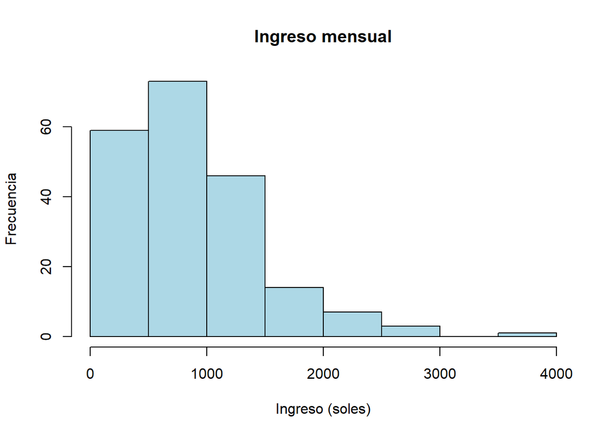

```r
hist(x = DF$Ingreso_mensual, main = "Ingreso mensual", xlab = "Ingreso (soles)", ylab = "Frecuencia", col = "lightblue")
```

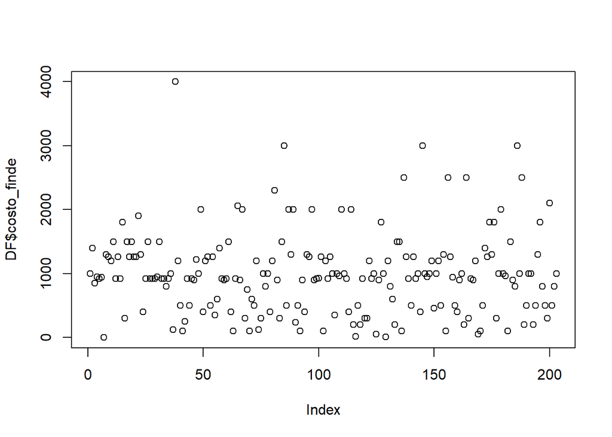

```r
plot(DF$Ingreso_mensual,DF$costo_finde)
```